# Term Project

DA4 Assignment 2

Dominik Gulacsy

25/03/2021

[GitHub Repository](https://github.com/dgulacsy/da4-term-project)

# 1 Introduction

Income/wealth inequality has become one of the most relevant topics in recent years. As many US. investors and founders have gained large amounts on the stock market in the last few years, growing their personal wealth to a level where some of them have higher net worth than some countries’ GDP. (ie.: Jeff Bezos has a higher net worth than Iraq, Hungary, Sudan, Ukraine, Morocco or Ecuador) As of these stunning revelations the discussion on income inequality is getting ever so vehement. Not surprisingly, the question may rise whether governments are able to fulfill one of their fundamental purpose: redistribution of income and wealth. As this is a broad and complex issue and I only have limited capacity to do the analysis, I focus only one particular aspect of it, taxation. I chose this as it is one of the primary tools of governments to redistribute income among individuals. Consequently, I aim to answer whether higher tax rates on commercial profits decrease income inequality.

# 2 Data Description

In this analysis I am using a dataset that I ensembled using mainly the [WDI](https://cran.r-project.org/web/packages/WDI/WDI.pdf) R package which enabled be to download indicators from the [World Bank](https://data.worldbank.org/indicator). My data is country level and I am considering the following variables for my analysis: Gini index, share of income owned by the bottom 10%, share of income owned by the top 10%, total tax rate on commercial profits (%), income category of the country, GDP/capita, total population, foreign investment (net inflow), strength of legal rights and ease of doing business. I queried the data from 2005 till 2019. As including either legal rights or ease of doing business result in a large share of observations being incomplete I decide not to use these potential confounder variables in my analysis. I showcase my variables that I use in this analysis in the table below.

[output not shown]

I decide to use Gini as my outcome variables and the tax rate (% of profit) as my causal variable. I also decide to run robustness checks by looking at the income gap (top 10% - bottom 10%) so I include it as well. I also decide not to use logs for these variables as keeping them in levels makes model interpretation much easier in this case. To the contrary, I took log of GDP/capita and total population as log changes in these variable can be approximately interpreted as percentage changes and thus they will be closer to normal distribution.

As I am interested in whether taxation is an effective governmental tool to mitigate income inequality I am not interested in the effect on the individual level. Consequently, I ruled out the usage of population as weights. To prepare data for first difference models I also took lagged differences of each variable.

I included the foreign investment variable as a confounder in my analysis since I think it affects both tax rates and income inequality. Firstly, businesses prefer to invest in countries that have lower tax rates. With this in mind, some countries may try to lower tax rates to incentivize foreign investment. I assume that there is at least a partially reverse relation between foreign investment and tax profit. Secondly, foreign investment is likely to widen the income inequality as generally high-income individuals benefit disproportionately more from foreign deals (ie.: building oil mining rigs).

As far as coverage is concerned, I have a rather unbalanced dataset. Missing values may pose a serious threat to the reliability of our results if datapoints are not missing randomly. Our estimates will be biased as this way there would be a systematic pattern in missing values. To handle this I decide to balance out the data so I discard those countries that have poor coverage for the 2005-2019 time period. I also take a look at how many periods each country has. To decide where to draw the line between poor and acceptable coverage I plot the distribution of countries regarding how many available datapoints they have. Based on that we can see that many countries only have 1-3 datapoints. However, there is also a fair amount of countries with around 13-15 available periods. By setting the threshold to 9 or more datapoints I keep 54 countries out 149 that have high availability. This is low enough to let us have the sufficient number of countries while not too low to have units with really poor coverage. Looking at the chart on the right we can see that we generally have about 50 countries for each year, on the other hand in some years it is less than half of the available countries for that given year. Furthermore, we can also see that 2019 data is not in for most countries.

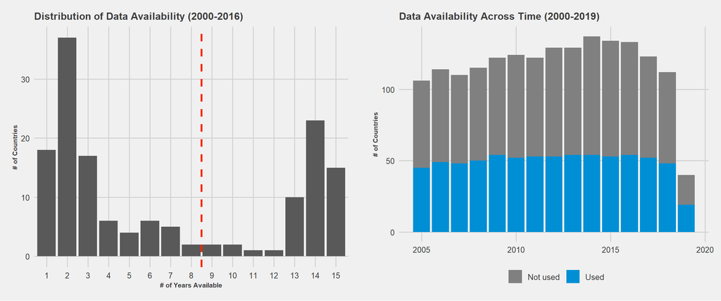

Looking at the distribution of key variables, we can say that they are skewed to the right but not in an extreme fashion. The tax rate variable has some extreme values but I deem them to be valid data points and I decide to include them in the analysis.

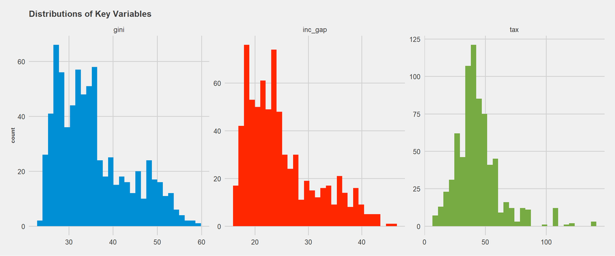

After looking at the data and thinking through my causal setup I decided to use a fixed effect regression with aggregate time trend as my primary model to estimate the effect I am looking for. I opted for this model as I am only interested in the long-term effect and I expect long-term effects to substantiate in a few years which means that FE probably gives a good approximation of the long-term effects. Another reason I chose this model type is the unbalanced nature of the dataset as FE regressions handle unbalanced data better.

# 3 Results & Robustness Checks

I run 4 fixed-effects regressions on the dataset. I created a baseline model without any confounders and I added two more by considering GDP/capita, population and foreign net investment as confounders. I also run a regression with a income gap being the outcome variable to check the robustness of my results, whether measuring a the income inequality with a slightly different metric would drastically change the interpretation. During the building of the models I paid attention not to include any variables that describe the capability or certain characteristics of governments as I believe these are part of the mechanism through which income inequality may potentially change thanks to change in tax rates.

Fixed Effect Models

|  | (1) FE Baseline Gini | (2) FE Controlled Gini | (3) FE Controlled Gini | (4) FE Controlled Income Gap |
| --- | --- | --- | --- | --- |
| Tax Rate (% of Profit) | -0.015 | -0.025 | -0.025 | -0.031 |
|  | (0.024) | (0.021) | (0.021) | (0.018) |
| ln(GDP/capita) |  | -7.875 *** | -7.851 *** | -6.117 ** |
|  |  | (2.023) | (2.025) | (1.779) |
| ln(Population) |  | -10.163 | -10.140 | -10.018 |
|  |  | (6.056) | (6.044) | (5.401) |
| Foreign Investment |  |  | -0.003 |  |
|  |  |  | (0.005) |  |
| Year dummies | Yes | Yes | Yes | Yes |
| Country-specific trends | Yes | Yes | Yes | Yes |
| N. obs. | 738 | 738 | 738 | 738 |
| Adj. R squared | 0.949 | 0.957 | 0.957 | 0.944 |
| F statistic |  |  |  |  |
| Within R squared is provided. Clustered standard errors are presented below in parentheses. *** p < 0.001; ** p < 0.01; * p < 0.05 Data: WDI (World Bank), unbalanced panel data with 54 countries betwe… |  |  |  |  |

Assessing the validity of the model I come out doubtful. Although I tried my best to get to the closest to the actual causal effect, I think there are many other confounder variables that influence the relationship in question. For example, I would include data on the general ownership structure of firms in different countries as this may affect both tax rates and income inequality.

First Difference Models

|  | (1) FD \| No Lags d_Gini | (2) FD \| 2 Lags d_Gini |
| --- | --- | --- |
| Chg. Tax Rate | -0.019 | -0.012 |
|  | (0.010) | (0.010) |
| Chg. Tax Rate Lag1 |  | 0.012 |
|  |  | (0.013) |
| Chg. Tax Rate Lag2 |  | 0.002 |
|  |  | (0.009) |
| ln(GDP/capita) | -3.924 ** | -2.365 |
|  | (1.417) | (1.627) |
| ln(Population) | -5.292 | -9.096 |
|  | (6.989) | (7.039) |
| Constant | -68.589 ** | -55.461 |
|  | (24.335) | (29.238) |
| Year dummies | Yes | Yes |
| N. obs. | 684 | 576 |
| Adj. R squared | 0.020 | 0.006 |
| F statistic | 3.331 | 1.335 |
| Clustered standard errors are presented below in parentheses. *** p < 0.001; ** p < 0.01; * p < 0.05 Data: WDI (World Bank), unbalanced panel data with 54 countries between 2005 and 2019. |  |  |